# Are words political?

The main power of modern stylometry comes from its ability to use **combined signals** from large number of features.  
This could be important not only for authorship attribution, because lexical features (words) contain different levels of texts redundantly: yes, words are great at providing us elusive dissimilarities of style, but they also contain chronology within them or are enough to predict genre of fiction (see [Underwood 2016](http://culturalanalytics.org/2016/05/the-life-cycles-of-genres/)).

It was shown many times that words are **political** too and could be used to trace partisan views and reveal deep differences in left and right discourses.

Here we will use supervised learning to see how (and if) large feature vectors exhibit a political alignment (or bias) in news dataset.

## Dataset

We use [American media dataset from Kaggle](https://www.kaggle.com/snapcrack/all-the-news) collected by Andrew Thompson.

Size: 143,000 publications from 15 media sources (2016-2017):

- The Atlantic
- Breibart
- Business Insider
- Buzzfeed News
- CNN
- Fox News
- The Guardian
- National Reviewb
- New York Post
- New York Times
- NPR
- Reuters
- Talking Points Memo
- Vox
- Washington Post

**Number of articles by the media:** // **Total aprox. length of all artices combined:**

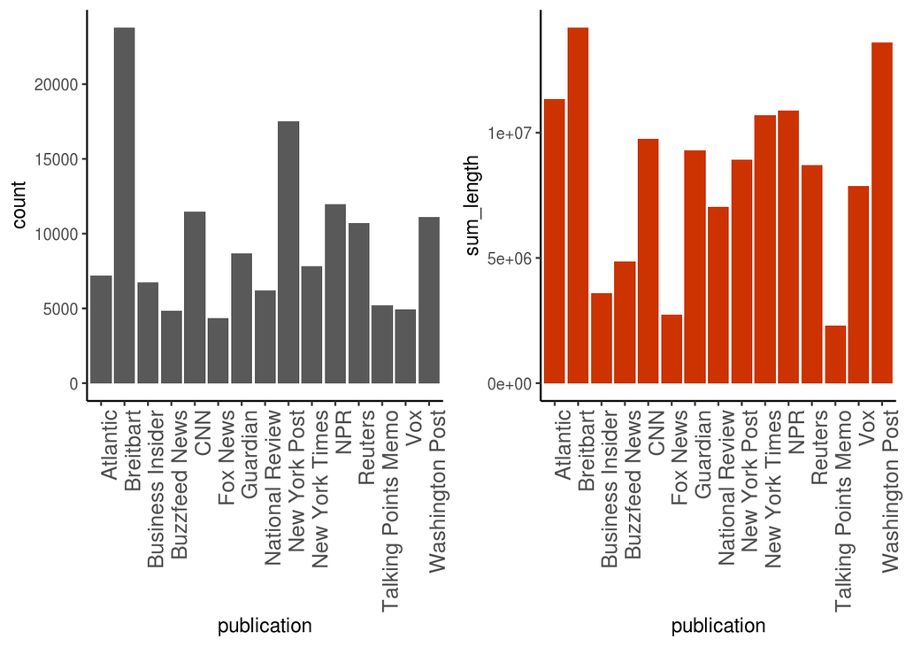

## Setting the experiment

Imagine you are an **alien researcher from xeno-sociology departement**. You got some old dataset from Earth with news from different media and you are studying very unclear human notion of “politics”. You don’t know what politics is, because your alien civilization don’t have any ideological variation at all and are governed by the jointed neural system of all individuals together.

But you know from the previous research that **some societies on the old Earth were aligning themselves to “right” and “left”** and it was somehow important for them. You also know that media played huge part in dissiminating various views and were somehow associated with different stances. However, these stances are not clear to you from the dataset at all: you can only figure out some more or less defined positions of few newspapers:

- Left: CNN, Vox, Talking Points Memo
- Right: Fox News, National Review

Others affiliations are strange:

- Left-Center: The Atlantic, Buzzfeed News, The Guardian, New York Times, NPR, Washington Post
- Center (non-partisan): Reuters
- Right-Center: New York Post
- Far-Right: Breibart

(Political biases are taken in accordance with [*Media Bias/Fact Check*](https://mediabiasfactcheck.com/) resource and could be biased as well)

Then you think that maybe the split is not so binary in the end! You decide that you need not to build a perfect classifier, but rather to test your **very assumption that political stance in media is binary**: how real is this “left” and “right” thing and is it traceable through language?

You decide to set up a simple experiment and write down the workflow:

1. Get the data and tag all media entries according to the (supposed) political bias;
2. Transform data to vectors of features (represent each entry large enough as vector of word frequencies);
3. Take media with **well-defined position** to represent **binary class** of political bias: **left / right**;
4. Train classifier **only** on these well-aligned media;
5. Use this **partisan classifier** on the test set of other random entries from your dataset with vague or extreme political stances;
6. See if classification to the “left” or “right” is purely random (50/50 classification per media) or completly deterministic (Left-Center would always classify as “left”).
7. Ponder the results.

## 1. Data manipulations

First, read all files from the folder **news_data/** and bind them into one large table.

```r
### list files with path from folder
files = list.files("news_data/", full.names = T)

### read csv files from files and combine tables together (in loop)
all_news = c()

for (i in files) {
  all_news = rbind(all_news, read_csv(i))
}
```

```r
### check the dataset
all_news
```

```
## # A tibble: 142,570 x 10
##       X1    id title publication author date        year month url
##    <dbl> <dbl> <chr> <chr>       <chr>  <date>     <dbl> <dbl> <chr>
##  1     0 17283 Hous… New York T… Carl … 2016-12-31  2016    12 <NA>
##  2     1 17284 Rift… New York T… Benja… 2017-06-19  2017     6 <NA>
##  3     2 17285 Tyru… New York T… Marga… 2017-01-06  2017     1 <NA>
##  4     3 17286 Amon… New York T… Willi… 2017-04-10  2017     4 <NA>
##  5     4 17287 Kim … New York T… Choe … 2017-01-02  2017     1 <NA>
##  6     5 17288 Sick… New York T… Sewel… 2017-01-02  2017     1 <NA>
##  7     6 17289 Taiw… New York T… Javie… 2017-01-02  2017     1 <NA>
##  8     7 17290 Afte… New York T… Gina … 2017-02-08  2017     2 <NA>
##  9     8 17291 Firs… New York T… Kathe… 2016-12-31  2016    12 <NA>
## 10     9 17292 Call… New York T… Andy … 2016-12-31  2016    12 <NA>
## # ... with 142,560 more rows, and 1 more variable: content <chr>
```

Finally we add new column **name_id** that combines in one string the id of an article, publication place and bias. We will need this to access classes of data later.

```r
# supplying political "leaning" for each media
## Left (L), Left-Center (LC), C (Center, Non-partisan), Right-Center (RC), Right (R), Far-Right (FR)
news_politics = all_news %>%
  count(publication) %>%
  mutate(bias = c("LC", "FR", "LC", "LC", "L", "R","LC","R", "RC", "LC", "LC", "C", "L", "L", "LC")) %>%
  left_join(all_news) %>%
# new name_id combining several variables
  mutate(name_id = paste(id, publication, bias, sep="_")) %>%
  select(-c(n, X1,date,month)) #remove some unused columns

news_politics
```

```
## # A tibble: 142,570 x 9
##    publication bias     id title    author   year url   content    name_id
##    <chr>       <chr> <dbl> <chr>    <chr>   <dbl> <chr> <chr>      <chr>
##  1 Atlantic    LC    73206 Obama: … Uri Fr…  2016 <NA>  As a pres… 73206_…
##  2 Atlantic    LC    73207 George … The Ed…  2016 <NA>  George Mi… 73207_…
##  3 Atlantic    LC    73208 The New… Megan …  2016 <NA>  “Reality … 73208_…
##  4 Atlantic    LC    73209 5 Numbe… Emily …  2016 <NA>  As a writ… 73209_…
##  5 Atlantic    LC    73210 The Atl… Candic…  2016 <NA>  This arti… 73210_…
##  6 Atlantic    LC    73211 What Wo… Conor …  2016 <NA>  If recent… 73211_…
##  7 Atlantic    LC    73212 The Atl… Yasmee…  2016 <NA>  This arti… 73212_…
##  8 Atlantic    LC    73213 Does An… David …  2016 <NA>  What is a… 73213_…
##  9 Atlantic    LC    73214 Ten Ame… James …  2016 <NA>  The end o… 73214_…
## 10 Atlantic    LC    73215 The Iro… Hayley…  2016 <NA>  This is t… 73215_…
## # ... with 142,560 more rows
```

Now, multivariate analysis with words as features usually makes sense only if a text is large enough. We should get rid of smaller articles and work only with larger opinion-pieces, essays or investigations. It would take too much resourses to tokenize entire corpus, so we will count the length of entries approximately: 1) count how many characters there are in text by **nchar()**, 2) divide by 5, ~avg. word length in English 3) filter articles shorter than 1000 words.

```r
news_politics = news_politics %>%
  mutate(length = nchar(content)/5) %>%
  filter(length > 1000)
```

## 2. Training and test sets

Time to build training and test sets for our classification experiment.

**Training set**: will contain data of two classes (R - “RIGHT”, L - “LEFT”) that classifier will learn to distinguish **Test set**: will contain “unseen” data of different classes which it will classify either to LEFT or RIGHT class.

Start with building training set. We take only **R** or **L** sources and randomly pick 500 articles for each class (first **group_by()** followed by **sample_n()**).

```r
news_train = news_politics %>%
  filter(bias %in% c("R", "L")) %>% #choose only R & L sources
  group_by(bias) %>% # group by the bias variable
  sample_n(500) %>% # when grouped sample_n() will take equal amount of samples from each value type in group
  mutate(set = "training") %>% # supply label to not lose info
  ungroup()
```

For the test set we will take 200 random samples from each other political affiliation outside left or right (“!” sign in R means NOT, so **!bias %in% c(“R”, “L”)** will work inversely, NOT including “R” or “L” values.

```r
news_test = news_politics %>%
  filter(!bias %in% c("R", "L")) %>%
  group_by(bias) %>%
  sample_n(200) %>%
  mutate(set = "test") %>%
  ungroup()
```

## 3. List of most frequent features (preparations)

We don’t clean texts properly here, but at least let’s exclude numbers and things alike: here we use a small trick by **filter(is.na(as.numeric(word)))**: it will leave only those values in “word” column that are not transformed to numeric (**as.numeric()**) and return NA (**is.na()**).

```r
rank = news_train %>%
  bind_rows(news_test) %>% #combine with test set for now
  unnest_tokens(input = content, output = word, token="words") %>% #unnest "content" column by words
  filter(is.na(as.numeric(word))) %>% #filter numericals out
  count(word,sort=T) %>% # count all occurences of words across set and arrange by frequency
  mutate(word_rank = row_number()) %>%
  filter(word_rank < 401) %>% # select MFWs that will be used later
  select(-n)

rank
```

```
## # A tibble: 400 x 2
##    word  word_rank
##    <chr>     <int>
##  1 the           1
##  2 to            2
##  3 of            3
##  4 and           4
##  5 a             5
##  6 in            6
##  7 that          7
##  8 is            8
##  9 for           9
## 10 on           10
## # ... with 390 more rows
```

## 4. Document-Term Matrices (counting and reshaping)

Now we can proceed to count words in both sets. **count(word, name_id)** ensures that words (“word” column) will be counted only within unique document names (name_id). Then **inner_join()** table with “rank” variable: so that only select Most Frequent Features (words) will remain. After this transfrom the tidy “long” table to wide and sparse “matrix” with **spread()**

```r
dtm_train = news_train %>%
  unnest_tokens(input = content, output = word, token="words") %>% # tokenize
  filter(is.na(as.numeric(word))) %>% # filter numericals
  count(word, name_id) %>% # count words within each document separately
  group_by(name_id) %>%
  mutate(n = n/sum(n)) %>% # get relative frequencies (% from the size). Because of "group_by" sum will only work for separate docs
  ungroup() %>%
  inner_join(rank, by="word") %>% # leave only words in MFW subset!
  select(-word_rank) %>%
  mutate(word = factor(word, levels = rank$word)) %>% # reorder future columns
  spread(key="word", value = "n", fill=0) # "spread" to "wide" table

dtm_test = news_test %>%
  unnest_tokens(input = content, output = word, token="words") %>%
  filter(is.na(as.numeric(word))) %>%
  count(word, name_id) %>%
  group_by(name_id) %>%
  mutate(n = n/sum(n)) %>%
  ungroup() %>%
  inner_join(rank, by="word") %>%
  select(-word_rank) %>%
  mutate(word = factor(word, levels = rank$word)) %>%
  spread(key="word", value = "n", fill=0)



dtm_train[1:10, 1:6]
```

```
## # A tibble: 10 x 6
##    name_id                     the     to     of    and      a
##    <chr>                     <dbl>  <dbl>  <dbl>  <dbl>  <dbl>
##  1 114716_National Review_R 0.0513 0.0357 0.0280 0.0241 0.0272
##  2 114722_National Review_R 0.0670 0.0134 0.0361 0.0206 0.0175
##  3 114787_National Review_R 0.0520 0.0241 0.0376 0.0385 0.0231
##  4 114807_National Review_R 0.0365 0.0163 0.0245 0.0370 0.0293
##  5 114838_National Review_R 0.0899 0.0135 0.0349 0.0242 0.0247
##  6 114852_National Review_R 0.0530 0.0228 0.0315 0.0134 0.0335
##  7 114887_National Review_R 0.0633 0.0312 0.0274 0.0343 0.0259
##  8 114912_National Review_R 0.0715 0.0196 0.0420 0.0322 0.0294
##  9 114916_National Review_R 0.0476 0.0204 0.0369 0.0408 0.0155
## 10 114918_National Review_R 0.0524 0.0208 0.0291 0.0333 0.0175
```

We will also need vector of document names in the proper (alphabetical) order, save for later:

```r
names_train = dtm_train %>%
  select(name_id)

names_test = dtm_test %>%
  select(name_id)

names_test
```

```
## # A tibble: 800 x 1
##    name_id
##    <chr>
##  1 100100_Buzzfeed News_LC
##  2 100572_Buzzfeed News_LC
##  3 102946_Buzzfeed News_LC
##  4 103564_Buzzfeed News_LC
##  5 104331_Buzzfeed News_LC
##  6 104601_Buzzfeed News_LC
##  7 106392_Buzzfeed News_LC
##  8 108965_Buzzfeed News_LC
##  9 109389_Buzzfeed News_LC
## 10 110497_Buzzfeed News_LC
## # ... with 790 more rows
```

## 5. Scaling

Now we have columns in proper and unified order. We do scaling the data in matrix form, so we remove names from the table. Don’t worry: the data is in the right order and we know it corresponds to vectors we have in **names_train** and **names_test** saved earlier!

```r
dtm_train = dtm_train[,2:ncol(dtm_train)] %>% # take data without fist column (name_id)
  as.matrix() %>% # transform to matrix
  scale() %>% # scale
  as.data.frame() # transform back to dataframe

dtm_test = dtm_test[,2:ncol(dtm_test)] %>%
  as.matrix() %>%
  scale() %>%
  as.data.frame()

dtm_train[1:10,1:6]
```

```
##           the         to          of        and          a          in
## 1  -0.5966073  0.9592536  0.06004938 -0.2053987  0.5664994  2.22575099
## 2   0.5909564 -2.2986427  1.13035773 -0.7009165 -0.8821613  1.39746458
## 3  -0.5406527 -0.7407544  1.32695901  1.8587838 -0.0438188 -0.09632363
## 4  -1.7111492 -1.8704436 -0.39715955  1.6396019  0.8837916  0.71913409
## 5   2.3221267 -2.2857127  0.96784948 -0.1934184  0.1976346  5.82826915
## 6  -0.4680581 -0.9276084  0.52858905 -1.7302119  1.5162939  1.18461240
## 7   0.3079547  0.3041684 -0.01028931  1.2534899  0.3746692 -1.07844543
## 8   0.9283372 -1.3916337  1.91737730  0.9587163  0.9017020  0.39498497
## 9  -0.8766735 -1.2798142  1.23734700  2.1789488 -1.1805743 -1.73513081
## 10 -0.5145313 -1.2224976  0.20810327  1.1036870 -0.8925610 -0.50761742
```

## 6. Support Vector Machine

For SVM classification we will use **perform.svm()** from [“stylo”](https://cran.r-project.org/web/packages/stylo/stylo.pdf) package. This is a more or less convenient wrapper around **e1071** package for machine learning, see the [source code here](https://rdrr.io/cran/stylo/src/R/perform.svm.R).

**perform.svm()** takes two tables (organized as DTM) as input: one for training set and one for test set. It trains classifier on the training set and then predicts classes for *unknown* data in the test set and compares them back with labels. Class lables should be supplied separately (otherwise it takes string before first underscore “THISSTRING_” as class label).

We have classes in **names_** variables and they correspond to our samples. The only thing we need is to extract them from a string with a name. We do it with **separate()**, provide separator (“_“) and define three new columns (”id“,”publication“,”bias“)

```r
class_train = names_train %>%
  separate(name_id, c("id", "publication", "bias"), sep="_")

class_test = names_test %>%
  separate(name_id, c("id", "publication", "bias"), sep="_")
```

Finally we can supply the model with everything it needs:

```r
svm_results = perform.svm(dtm_train, # training set
                          dtm_test,  # test set
                          classes.training.set = class_train$bias, # training classes (which classes will be predicted)
                          classes.test.set = class_test$bias, # test classes (which classes will be compared with predicted)
                          svm.kernel = "linear", # standart SVM kernel is linear (hyperplane is a line)
                          svm.degree = 3, #for polynomial kernel
                          svm.coef0 = 0,  #for polynomial kernel
                          svm.cost = 1)
```

## 7. Results

We can access “confusion” matrix from the results: how actual classes in the test set were predicted as RIGHT or LEFT?

```r
attr(svm_results, "confusion_matrix")
```

```
##                  actual_classes
## predicted_classes   C  FR  LC  RC
##                 L 104  76 121 109
##                 R  96 124  79  91
```

Using this data you can, for examples, visualise the shares of R & L attributions in each test class (political bias media)

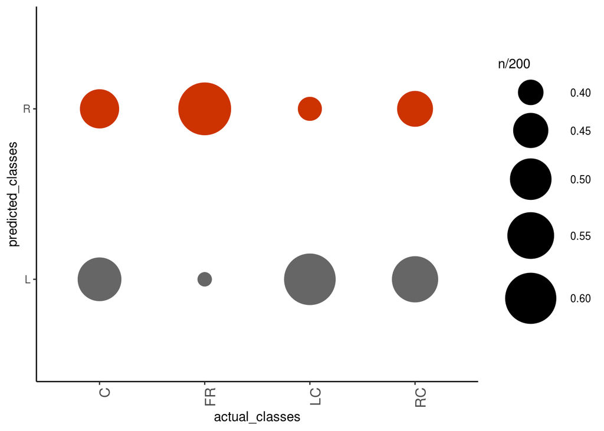

```r
as_tibble(attr(svm_results, "confusion_matrix")) %>%
  ggplot(aes(actual_classes, predicted_classes)) + geom_point(aes(size=n/200,color=predicted_classes)) +
  scale_size_continuous(range = c(5, 20)) +
  theme_classic() +
  scale_color_manual(values=c("#666666", "#cc3300")) +
  guides(color=F) +
  theme(axis.text.x = element_text(size=12,angle = 90, hjust = 1))
```

It appears (at least in my several runs), that LEFT and RIGHT discourses are **somewhat existing and exhibiting lexical signal**. They have some predictive power, but the classifier is overall pretty weak. Moreover, it seems that LEFT discourse is inflated: many things that are not FAR RIGHT are actually leaning towards the LEFT.  
As a **xeno-sociologist** you may assume two things:

1. Real “central” position in journalism on Earth during 2016-2017 was somewhere near moderate LEFT (the position of common sense: even Right-Center is closer to LEFT than to RIGHT);
2. The labels of political bias are biased themselves: maybe Left-Center media is much more “central” and neutral than is tagged.

You decide to run classificaiton on separate media sources, not the bias labels!